# COMPARE HSP2 TO HSPF USING TEST10

[figure not shown]

Copyright 2020 for this Jupyter Notebook and YouTube Video by RESPEC, INC. All rights reserved.

$\textbf{HSP}^{\textbf{2}}\ \text{and}\ \textbf{HSP2}\ $ Copyright 2020 by RESPEC INC. and released under the *GNU AFFERO GENERAL PUBLIC LICENSE*

This Notebook will compare the results of running HSPF and HSP$^2$ for the basic hydrology (PWATER, IWATER, and HYDR) to confirm the proper calculations of HSP$^2$

Calleg is a real watershed and has

- 27 IMPLND segments,
- 129 PERLND segments,
- 119 RCHRES segments,
- 9 years of simulation time with hourly time steps (78,888 timesteps) from 1993-10-01 to 2002-10-01

This Notebook assumes HSPF has been run and the HBN data saved to an HDF5 file in the **HSPF RUN** directory.

```python
# Optional setting to testing Numba
import os
os.environ['NUMBA_DISABLE_JIT'] = '0' # '1' turns off Numba for this session only
```

## Required Python imports and setup

```python
from pandas import options, read_hdf, DataFrame
from matplotlib import pyplot as plt

# Set display options for convenience, does't change the data
options.display.max_rows    = 150
options.display.max_columns = 20
options.display.float_format = '{:.4f}'.format  # display 4 digits after the decimal point

%matplotlib inline

from HSP2 import main, versions
from HSP2tools import readWDM, readUCI
versions(['matplotlib', 'tables', 'h5py'])
```

|  | version |
| --- | --- |
| Python | 3.8.8 \| packaged by conda-forge \| (default, Fe... |
| HSP2 | 0.9.1 |
| numpy | 1.20.2 |
| numba | 0.53.1 |
| pandas | 1.2.3 |
| matplotlib | 3.4.1 |
| tables | 3.6.1 |
| h5py | 3.1.0 |
| os | macOS-10.15.7-x86_64-i386-64bit |
| processor | i386 |
| Date/Time | 2021-03-31 17:03:56 |

Convenient name strings to get to the data

```python
wdmname = 'test10.wdm'
uciname = 'test10.uci'
HBN     = 'test10_hspf.h5'
hdfname = 'test10_hsp2_dev2WDM.h5'
```

## Run HSP2 on the calleg

### Create HDF5 file

```python
%time
readUCI(uciname, hdfname)
```

```
CPU times: user 2 µs, sys: 0 ns, total: 2 µs
Wall time: 4.77 µs
```

```python
%time
readWDM(wdmname, hdfname)
```

```
CPU times: user 1e+03 ns, sys: 0 ns, total: 1e+03 ns
Wall time: 3.81 µs
39 reading from wdm
41 reading from wdm
42 reading from wdm
46 reading from wdm
113 reading from wdm
119 reading from wdm
121 reading from wdm
122 reading from wdm
123 reading from wdm
124 reading from wdm
125 reading from wdm
126 reading from wdm
127 reading from wdm
131 reading from wdm
132 reading from wdm
134 reading from wdm
135 reading from wdm
136 reading from wdm
140 reading from wdm
```

|  | Start | Stop | Freq | Length | TSTYPE | TFILL | STAID | STNAM |
| --- | --- | --- | --- | --- | --- | --- | --- | --- |
| TS039 | 1976-01-01 00:00:00 | 1976-12-31 23:00:00 | 1H | 8784 | PREC | -999.0000 | HOURLY PREC | PRECIP TRAER IOWA |
| TS041 | 1976-01-01 00:00:00 | 1976-12-31 00:00:00 | 1D | 366 | EVAP | -999.0000 | DAILY EVAP | FARMERS COOP WEATHER STN |
| TS042 | 1976-01-01 00:00:00 | 1976-12-31 00:00:00 | 1D | 366 | WIND | -999.0000 | DAILY WIND | FARMERS COOP WEATHER STN |
| TS046 | 1976-01-01 00:00:00 | 1976-12-31 22:00:00 | 2H | 4392 | SOLR | -999.0000 | 2 HOUR RAD | FARMERS WEATHER STN |
| TS113 | 1976-01-01 00:00:00 | 1976-12-31 00:00:00 | 1D | 366 | FLOW | -999.0000 | DAILY FLOW | IOWA RIVER MARSHALLTOWN |
| TS119 | 1976-01-01 00:00:00 | 1976-12-31 00:00:00 | 1D | 366 | FLOW | -999.0000 | DAILY FLOW | IOWA RIVER MARENGO |
| TS121 | 1976-01-01 00:00:00 | 1976-12-31 22:00:00 | 2H | 4392 | ATMP | -999.0000 | 2 HOUR AIR TEMP | CEDAR RAPIDS IOWA |
| TS122 | 1976-01-01 00:00:00 | 1976-12-31 22:00:00 | 2H | 4392 | ATMP | -999.0000 | 2 HOUR AIR TEMP | IOWA FALLS IOWA |
| TS123 | 1976-01-01 00:00:00 | 1976-12-31 22:00:00 | 2H | 4392 | ATMP | -999.0000 | 2 HOUR AIR TEMP | MARSHALLTOWN IOWA |
| TS124 | 1976-01-01 00:00:00 | 1976-12-31 00:00:00 | 1D | 366 | DEWP | -999.0000 | DAILY DEW PT | CEDAR RAPIDS IOWA |
| TS125 | 1976-01-01 00:00:00 | 1976-12-31 00:00:00 | 1D | 366 | DEWP | -999.0000 | DAILY DEW PT | IOWA FALLS IOWA |
| TS126 | 1976-01-01 00:00:00 | 1976-12-31 00:00:00 | 1D | 366 | DEWP | -999.0000 | DAILY DEW PT | MARSHALLTOWN IOWA |
| TS127 | 1976-01-01 00:00:00 | 1976-12-31 00:00:00 | 1D | 366 | SEDM | -999.0000 | SEDIMENT CONC | IOWA RIVER MARENGO |
| TS131 | 1976-01-01 00:00:00 | 1976-12-31 23:00:00 | 1H | 8784 | PREC | -999.0000 | HOURLY PREC | PRECIP IOWA FALLS |
| TS132 | 1976-01-01 00:00:00 | 1976-12-31 23:00:00 | 1H | 8784 | PREC | -999.0000 | HOURLY PREC | PRECIP SHEFFIELD |
| TS134 | 1976-01-01 00:00:00 | 1976-12-31 00:00:00 | 1D | 366 | WTMP | -999.0000 | WATER TEMP | IOWA RIVER (ESTIMATED) |
| TS135 | 1976-01-01 00:00:00 | 1976-12-31 00:00:00 | 1D | 366 | CLDC | -999.0000 | CLOUD COVER | WATERLOO (TENTHS) |
| TS136 | 1976-01-01 00:00:00 | 1976-12-31 00:00:00 | 1D | 366 | FLOW | -999.0000 | DAILY FLOW | IOWA RIVER ROWAN |
| TS140 | 1976-01-01 00:00:00 | 1976-12-31 00:00:00 | 1D | 366 | CLND | -999.0000 | COLIND | COLUMN INDICATOR MEIER POND SUMMER-WINTER OUTLET |

### Run

Using profiler

```python
%%prun  -l 60 -T NumbaProfile.txt -q
main(hdfname, saveall=True)
```

```
2021-03-31 17:10:15.05   Processing started for file test10_hsp2_dev2WDM.h5; saveall=True
2021-03-31 17:10:20.94   Simulation Start: 1976-01-01 00:00:00, Stop: 1977-01-01 00:00:00
2021-03-31 17:10:20.94      PERLND P001 DELT(minutes): 60
2021-03-31 17:10:23.53         SNOW
2021-03-31 17:10:25.90         PWATER
2021-03-31 17:10:25.99         PSTEMP
2021-03-31 17:10:26.04         PWTGAS
2021-03-31 17:10:26.11      RCHRES R001 DELT(minutes): 60
2021-03-31 17:10:26.27         HYDR
2021-03-31 17:10:26.64         ADCALC
2021-03-31 17:10:26.83         CONS
2021-03-31 17:10:26.88         HTRCH
2021-03-31 17:10:26.96         SEDTRN
2021-03-31 17:10:27.17         GQUAL
```

[output not shown]

```python
with open('NumbaProfile.txt', 'r') as f:
    for line in f:
        total = float(line.split()[7])
        print(line)
        f.readline()
        f.readline()
        f.readline()
        f.readline()
        print(f.readline().rstrip())
        break
    sum = 0.0
    for line in f:
        sum += float(line.split()[1])
        print(line.rstrip())

        # Pareto rule, look for calls cumsum to 80% time, ignore the rest
        if sum >= 0.8 * total:
            break
print(f'Cum Sum {100.0 * sum/total:.2f}%')
```

```
         14718179 function calls (14467077 primitive calls) in 19.043 seconds

   ncalls  tottime  percall  cumtime  percall filename:lineno(function)
        5    2.339    0.468    6.400    1.280 GQUAL.py:18(gqual)
    46083    1.198    0.000    1.198    0.000 {method '_g_getattr' of 'tables.hdf5extension.AttributeSet' objects}
        5    0.950    0.190    1.580    0.316 SEDTRN.py:13(sedtrn)
    18899    0.946    0.000    0.946    0.000 {method '_g_get_objinfo' of 'tables.hdf5extension.Group' objects}
   258685    0.848    0.000    2.396    0.000 typeddict.py:147(__getitem__)
     4700    0.538    0.000    0.716    0.000 {method '_open_array' of 'tables.hdf5extension.Array' objects}
     4869    0.449    0.000    0.449    0.000 {method '_g_get_lchild_attr' of 'tables.hdf5extension.Group' objects}
    23258    0.340    0.000    0.384    0.000 GQUAL.py:1149(adsdes)
    23258    0.336    0.000    0.403    0.000 GQUAL.py:1266(ddecay)
   418644    0.336    0.000    0.336    0.000 GQUAL.py:1329(light_factor)
        5    0.328    0.066    0.435    0.087 HTRCH.py:39(htrch)
   284191    0.314    0.000    1.174    0.000 dispatcher.py:677(typeof_pyval)
```

[output cut: 49 more lines]

## BELOW HERE: Output from Steve's testing

Normal run

```python
main(hdfname, saveall=True)
```

```
2020-11-04 20:43:22.36   Processing started for file hsp2.h5; saveall=True
2020-11-04 20:43:27.86   Simulation Start: 1976-01-01 00:00:00, Stop: 1977-01-01 00:00:00
2020-11-04 20:43:27.86      PERLND P001 DELT(minutes): 60
2020-11-04 20:43:31.54         SNOW
2020-11-04 20:43:51.30         PWATER
2020-11-04 20:43:51.48      RCHRES R001 DELT(minutes): 60
2020-11-04 20:43:51.72         HYDR
2020-11-04 20:43:52.31      RCHRES R002 DELT(minutes): 60
2020-11-04 20:43:52.47         HYDR
2020-11-04 20:43:52.68      RCHRES R003 DELT(minutes): 60
2020-11-04 20:43:52.85         HYDR
2020-11-04 20:43:52.97      RCHRES R004 DELT(minutes): 60
2020-11-04 20:43:53.16         HYDR
2020-11-04 20:43:53.33      IMPLND I001 DELT(minutes): 60
2020-11-04 20:43:53.54         SNOW
2020-11-04 20:43:53.67         IWATER
2020-11-04 20:43:53.76      RCHRES R005 DELT(minutes): 60
2020-11-04 20:43:53.94         HYDR
2020-11-04 20:43:54.10   Done; Run time is about 00:31.7 (mm:ss)


                                                       version
Python      3.8.2 | packaged by conda-forge | (default, Ap...
HSP2                                                    1.0.0
numpy                                                  1.18.1
numba                                                  0.48.0
pandas                                                  1.0.3
jupyterlab                                              2.1.1
notebook                                                6.0.3
os                                  Windows-10-10.0.19041-SP0
processor   Intel64 Family 6 Model 142 Stepping 9, Genuine...
Date/Time                                 2020-11-04 20:43:54
```

Development note: SAVEALL = FALSE (new SAVE table for hot restart by default) 2017-04-16 09:05:26.10 Run completed 1 loop, best of 3: 32.3 s per loop Ratio of HSP2/HSPF 32.3/24.4 = 1.3 SAVEALL = TRUE 2017-04-11 10:18:22.86 Run completed 1 loop, best of 3: 38.1 s per loop Ratio of HSP2/HSPF 38.1/24.4 = 1.6 04/25/2020 New Python 3 version is about 1.8x slower than HSPF - even when all tricks used. However, the new Numba Dict and List implementations are SLOW in the code outside numba - on the order of us vs ns which can easily explain a slight difference. Spotted warning messages in HSP2 log file. 05/04/2020 new Calleg testing For reference the run time of HSPF is 32.2 seconds. Using to_hdf() With Flush - create test10.h5 Run time is about 01:56.9 size 2,136,787 KB existing test10.h5 Run time is about 01:15.2 size 2,136,836 KB NO Flush - create test10.h5 Run time is about 01:19.1 size 2,136,787 KB Warning messages seen for closed node existing test10.h5 Run time is about 01:14.4 size 2,236,836 KB BLOSC - create test10.h5 Run time is about 01:29.0 size 1,156,499 KB No Flush, but no warning messages (Blosc in save_timeseries only) existing test10.h5 Run time is about 01:26.2 size 1,156,796 KB BLOSC (wdm & main) - create test10.h5 Run time is about 01:30.8 size 1,050,043 KB No Flush, no warning messages. existing test10.h5 Run time is about 01:26.0 size 1,060,340 KB existing test10.h5 Run time is about 01:23.6 (5/8/2020) existing test10.h5 Run time is about 01:19.7 (5/8/2020) - no kernel restart from last run NO Numba - existing test10.h5 Run time is about 13:25.1 or x9.4 slower than with Numba. So current timing results show HSP2 is 2.8x slower than HSPF for this problem. Also tried return to store.put() with BLOSC (wdm & main) instead of to_hdf() - existing test10.h5 Run time is about 01:28.0 but found warning messages for closed node. Speedup not worth it.

## Read Summary from HBN file

Find the higest frequency data available.

```python
summary = read_hdf(HBN, 'SUMMARY')
summary.Frequency.unique()
```

[output not shown]

## Automate checking by output flow

```python
def hsp2key(hspfkey):
    op, activity, segment, _ = hspfkey.split('_')
    return  f'RESULTS/{op}_{op[0]}{segment:0>3s}/{activity}'
```

```python
def monthlyoutflow(keys, flowname):
    data = DataFrame()
    for key in keys.index:
        hsp2 = read_hdf(hdfname, hsp2key(key))[flowname].resample('M').sum().to_numpy()
        hspf = read_hdf(HBN, key)[flowname].to_numpy()

        hsp2sum = hsp2.sum()
        hspfsum = hspf.sum()

        segment = key.split('_')[2]

        data.loc[segment, 'HSP2 SUM'] = hsp2.sum()
        data.loc[segment, 'HSPF SUM'] = hspf.sum()
        data.loc[segment, 'Percent diff']      = 100.0 *    (hspfsum - hsp2sum)/hspfsum
        data.loc[segment, 'abs(Percent diff)'] = 100.0 * abs(hspfsum - hsp2sum)/hspfsum

    return data.sort_values(by=['abs(Percent diff)'])
```

### Define a function to plot HSPF and HSP2 data

```python
def plot(operation, ils, activity, name, how='sum'):
    hspf = f'{operation}_{activity}_{ils:0>3s}_4'
    tshspf = read_hdf(HBN, hspf)[name]

    hsp2 = f'RESULTS/{operation}_{operation[0]}{ils:0>3s}/{activity}'
    if how == 'sum':
        tshsp2 = read_hdf(hdfname, hsp2)[name].resample('M').sum().shift(1,'D')
    elif how == 'last':
        tshsp2 = read_hdf(hdfname, hsp2)[name].resample('M').last().shift(1,'D')

    plt.figure(figsize=(10,8))
    plt.plot(tshspf.index, tshspf, label='HSPF', color='r')
    plt.plot(tshsp2.index, tshsp2, label='HSP2', color='b')
    plt.legend()
    plt.title(f'{operation} {operation[0]}{ils:0>3s}, {activity} {name}')
```

```python
def scatter(operation, ils, activity, name, how='sum'):
    hspf = f'{operation}_{activity}_{ils:0>3s}_4'
    tshspf = read_hdf(HBN, hspf)[name]

    hsp2 = f'RESULTS/{operation}_{operation[0]}{ils:0>3s}/{activity}'
    if how == 'sum':
        tshsp2 = read_hdf(hdfname, hsp2)[name].resample('M').sum().shift(1,'D')
    elif how == 'last':
        tshsp2 = read_hdf(hdfname, hsp2)[name].resample('M').last().shift(1,'D')

    plt.scatter(tshspf, tshsp2)
```

### IMPLND

```python
implndkeys = summary[(summary.Frequency=='Monthly') & (summary.Operation=='IMPLND')]
implndkeys[0:10]
```

|  | Operation | Activity | segment | Frequency | Shape | Start | Stop |
| --- | --- | --- | --- | --- | --- | --- | --- |
| IMPLND_IWATER_011_4 | IMPLND | IWATER | 11 | Monthly | (108, 6) | 1993-11-01 | 2002-10-01 |
| IMPLND_IWATER_021_4 | IMPLND | IWATER | 21 | Monthly | (108, 6) | 1993-11-01 | 2002-10-01 |
| IMPLND_IWATER_041_4 | IMPLND | IWATER | 41 | Monthly | (108, 6) | 1993-11-01 | 2002-10-01 |
| IMPLND_IWATER_051_4 | IMPLND | IWATER | 51 | Monthly | (108, 6) | 1993-11-01 | 2002-10-01 |
| IMPLND_IWATER_061_4 | IMPLND | IWATER | 61 | Monthly | (108, 6) | 1993-11-01 | 2002-10-01 |
| IMPLND_IWATER_071_4 | IMPLND | IWATER | 71 | Monthly | (108, 6) | 1993-11-01 | 2002-10-01 |
| IMPLND_IWATER_081_4 | IMPLND | IWATER | 81 | Monthly | (108, 6) | 1993-11-01 | 2002-10-01 |
| IMPLND_IWATER_101_4 | IMPLND | IWATER | 101 | Monthly | (108, 6) | 1993-11-01 | 2002-10-01 |
| IMPLND_IWATER_111_4 | IMPLND | IWATER | 111 | Monthly | (108, 6) | 1993-11-01 | 2002-10-01 |
| IMPLND_IWATER_121_4 | IMPLND | IWATER | 121 | Monthly | (108, 6) | 1993-11-01 | 2002-10-01 |

```python
delta = monthlyoutflow(implndkeys, 'SURO')
delta
```

|  | HSP2 SUM | HSPF SUM | Percent diff | abs(Percent diff) |
| --- | --- | --- | --- | --- |
| 291 | 117.5699 | 117.5699 | -0.0000 | 0.0000 |
| 281 | 137.7904 | 137.7904 | 0.0000 | 0.0000 |
| 101 | 144.1288 | 144.1288 | -0.0000 | 0.0000 |
| 021 | 122.5966 | 122.5966 | 0.0000 | 0.0000 |
| 051 | 120.2708 | 120.2708 | 0.0000 | 0.0000 |
| 081 | 118.7938 | 118.7938 | -0.0000 | 0.0000 |
| 041 | 141.2890 | 141.2890 | 0.0000 | 0.0000 |
| 271 | 136.4228 | 136.4228 | 0.0000 | 0.0000 |
| 251 | 116.6337 | 116.6337 | 0.0000 | 0.0000 |
| 201 | 172.5608 | 172.5608 | -0.0000 | 0.0000 |
| 191 | 125.6937 | 125.6937 | 0.0000 | 0.0000 |
| 221 | 126.6460 | 126.6460 | 0.0000 | 0.0000 |
| 071 | 132.6849 | 132.6849 | 0.0000 | 0.0000 |
| 111 | 126.0203 | 126.0203 | 0.0000 | 0.0000 |
| 141 | 116.0248 | 116.0249 | 0.0000 | 0.0000 |
| 131 | 126.2947 | 126.2947 | 0.0000 | 0.0000 |
| 121 | 126.2947 | 126.2947 | 0.0000 | 0.0000 |
| 161 | 131.2695 | 131.2695 | 0.0000 | 0.0000 |
| 211 | 125.3008 | 125.3008 | -0.0000 | 0.0000 |
| 011 | 131.6821 | 131.6821 | 0.0000 | 0.0000 |
| 151 | 133.6036 | 133.6036 | 0.0000 | 0.0000 |
| 061 | 133.6036 | 133.6036 | 0.0000 | 0.0000 |
| 301 | 119.8081 | 119.8081 | -0.0000 | 0.0000 |
| 171 | 115.9610 | 115.9610 | 0.0000 | 0.0000 |
| 181 | 115.9610 | 115.9610 | 0.0000 | 0.0000 |
| 241 | 120.2066 | 120.2066 | 0.0000 | 0.0000 |
| 231 | 135.5890 | 135.5890 | 0.0000 | 0.0000 |

Look at the statistics for the percent difference column

```python
delta.describe()
```

|  | HSP2 SUM | HSPF SUM | Percent diff | abs(Percent diff) |
| --- | --- | --- | --- | --- |
| count | 27.0000 | 27.0000 | 27.0000 | 27.0000 |
| mean | 128.5445 | 128.5445 | 0.0000 | 0.0000 |
| std | 12.0012 | 12.0012 | 0.0000 | 0.0000 |
| min | 115.9610 | 115.9610 | -0.0000 | 0.0000 |
| 25% | 120.0074 | 120.0074 | 0.0000 | 0.0000 |
| 50% | 126.2947 | 126.2947 | 0.0000 | 0.0000 |
| 75% | 133.6036 | 133.6036 | 0.0000 | 0.0000 |
| max | 172.5608 | 172.5608 | 0.0000 | 0.0000 |

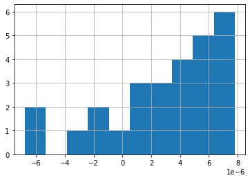

```python
delta['Percent diff'].hist()
```

```python
ils = delta.index[-1]
print('WORST IMPLND SEGMENT IS', ils)
```

```
WORST IMPLND SEGMENT IS 231
```

#### IMPLND IWATER SURO, Monthly

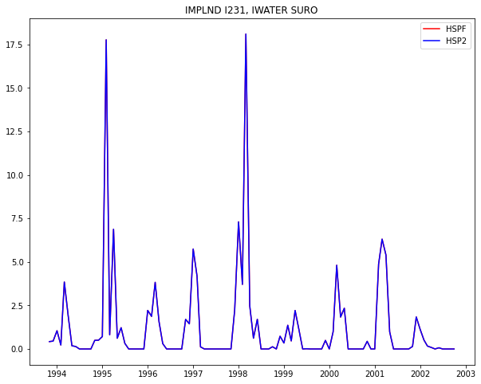

```python
plot('IMPLND', ils, 'IWATER', 'SURO', 'sum')
```

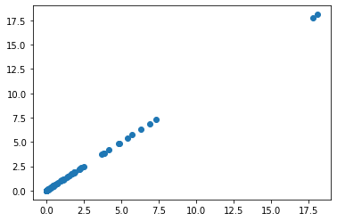

```python
scatter('IMPLND', ils, 'IWATER', 'SURO', 'sum')
```

#### IMPLND IWATER IMPEV, Monthly

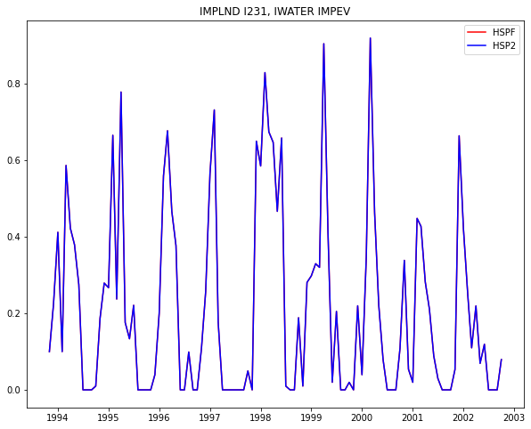

```python
plot('IMPLND', ils, 'IWATER', 'IMPEV', 'sum')
```

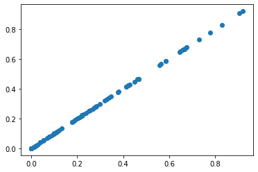

```python
scatter('IMPLND', ils, 'IWATER', 'IMPEV', 'sum')
```

#### IMPLND IWATER PET, Monthly

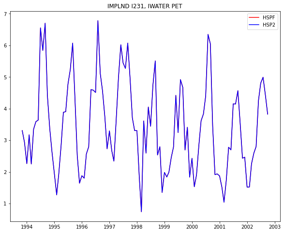

```python
plot('IMPLND', ils, 'IWATER', 'PET', 'sum')
```

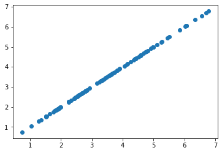

```python
scatter('IMPLND', ils, 'IWATER', 'PET', 'sum')
```

#### IMPLND IWATER RETS, Monthly

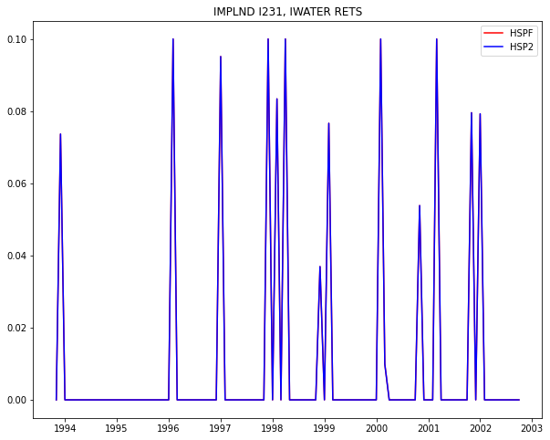

```python
plot('IMPLND', ils, 'IWATER', 'RETS', 'last')
```

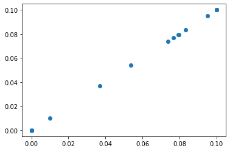

```python
scatter('IMPLND', ils, 'IWATER', 'RETS', 'last')
```

#### IMPLND IWATER SUPY, Monthly

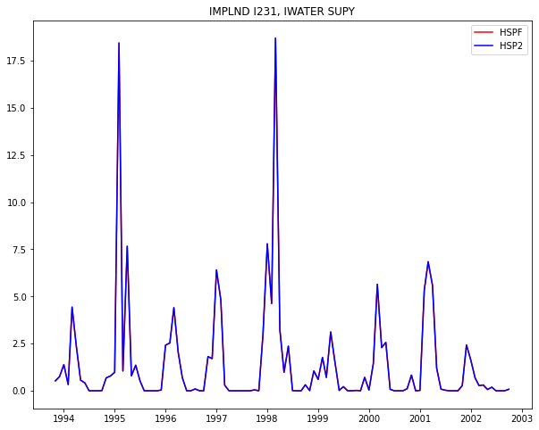

```python
plot('IMPLND', ils, 'IWATER', 'SUPY', 'sum')
```

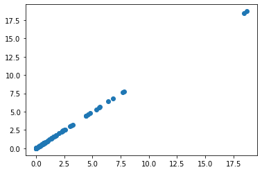

```python
scatter('IMPLND', ils, 'IWATER', 'SUPY', 'sum')
```

#### IMPLND IWATER SURS, Monthly

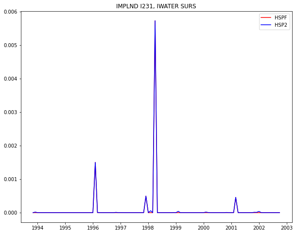

```python
plot('IMPLND', ils, 'IWATER', 'SURS', 'last')
```

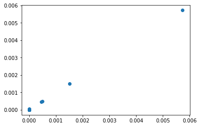

```python
scatter('IMPLND', ils, 'IWATER', 'SURS', 'last')
```

## Automate checking PERLNDs for PERO

```python
perlndkeys = summary[(summary.Frequency=='Monthly') & (summary.Operation=='PERLND')]
perlndkeys[0:10]
```

|  | Operation | Activity | segment | Frequency | Shape | Start | Stop |
| --- | --- | --- | --- | --- | --- | --- | --- |
| PERLND_PWATER_011_4 | PERLND | PWATER | 11 | Monthly | (108, 27) | 1993-11-01 | 2002-10-01 |
| PERLND_PWATER_012_4 | PERLND | PWATER | 12 | Monthly | (108, 32) | 1993-11-01 | 2002-10-01 |
| PERLND_PWATER_013_4 | PERLND | PWATER | 13 | Monthly | (108, 32) | 1993-11-01 | 2002-10-01 |
| PERLND_PWATER_014_4 | PERLND | PWATER | 14 | Monthly | (108, 32) | 1993-11-01 | 2002-10-01 |
| PERLND_PWATER_015_4 | PERLND | PWATER | 15 | Monthly | (108, 32) | 1993-11-01 | 2002-10-01 |
| PERLND_PWATER_021_4 | PERLND | PWATER | 21 | Monthly | (108, 27) | 1993-11-01 | 2002-10-01 |
| PERLND_PWATER_022_4 | PERLND | PWATER | 22 | Monthly | (108, 32) | 1993-11-01 | 2002-10-01 |
| PERLND_PWATER_023_4 | PERLND | PWATER | 23 | Monthly | (108, 32) | 1993-11-01 | 2002-10-01 |
| PERLND_PWATER_024_4 | PERLND | PWATER | 24 | Monthly | (108, 32) | 1993-11-01 | 2002-10-01 |
| PERLND_PWATER_025_4 | PERLND | PWATER | 25 | Monthly | (108, 32) | 1993-11-01 | 2002-10-01 |

```python
delta = monthlyoutflow(perlndkeys, 'PERO')
delta
```

|  | HSP2 SUM | HSPF SUM | Percent diff | abs(Percent diff) |
| --- | --- | --- | --- | --- |
| 055 | 64.7859 | 64.7859 | -0.0000 | 0.0000 |
| 226 | 29.4270 | 29.4270 | -0.0000 | 0.0000 |
| 222 | 45.9145 | 45.9145 | -0.0000 | 0.0000 |
| 124 | 56.8129 | 56.8129 | -0.0000 | 0.0000 |
| 235 | 85.6543 | 85.6543 | -0.0000 | 0.0000 |
| 071 | 13.8709 | 13.8709 | -0.0000 | 0.0000 |
| 275 | 44.8519 | 44.8519 | 0.0000 | 0.0000 |
| 135 | 49.4472 | 49.4472 | -0.0000 | 0.0000 |
| 023 | 57.9035 | 57.9035 | -0.0000 | 0.0000 |
| 201 | 10.9715 | 10.9715 | -0.0000 | 0.0000 |
| 082 | 45.8386 | 45.8386 | 0.0000 | 0.0000 |
| 285 | 97.2315 | 97.2314 | -0.0000 | 0.0000 |
| 304 | 104.4457 | 104.4457 | 0.0000 | 0.0000 |
| 232 | 54.5515 | 54.5515 | 0.0000 | 0.0000 |
| 256 | 21.2304 | 21.2304 | 0.0000 | 0.0000 |
| 051 | 10.1520 | 10.1520 | 0.0000 | 0.0000 |
| 175 | 56.6028 | 56.6028 | -0.0000 | 0.0000 |
| 295 | 121.6003 | 121.6003 | 0.0000 | 0.0000 |
| 013 | 55.6965 | 55.6965 | 0.0000 | 0.0000 |
| 254 | 46.5186 | 46.5186 | -0.0000 | 0.0000 |
| 225 | 70.3941 | 70.3940 | -0.0000 | 0.0000 |
| 072 | 54.2092 | 54.2092 | 0.0000 | 0.0000 |
| 102 | 37.5410 | 37.5410 | -0.0000 | 0.0000 |
| 291 | 31.4601 | 31.4601 | -0.0000 | 0.0000 |
| 073 | 65.6017 | 65.6017 | -0.0000 | 0.0000 |
| 184 | 52.1066 | 52.1066 | -0.0000 | 0.0000 |
| 281 | 12.5471 | 12.5471 | -0.0000 | 0.0000 |
| 075 | 73.6297 | 73.6297 | 0.0000 | 0.0000 |
| 206 | 28.4453 | 28.4453 | -0.0000 | 0.0000 |
| 164 | 49.3031 | 49.3031 | 0.0000 | 0.0000 |

[output cut: 99 more lines]

Look at the statistics for the percent difference column

```python
delta.describe()
```

|  | HSP2 SUM | HSPF SUM | Percent diff | abs(Percent diff) |
| --- | --- | --- | --- | --- |
| count | 129.0000 | 129.0000 | 129.0000 | 129.0000 |
| mean | 45.5122 | 45.5122 | -0.0000 | 0.0001 |
| std | 26.6657 | 26.6657 | 0.0001 | 0.0000 |
| min | 4.6437 | 4.6437 | -0.0003 | 0.0000 |
| 25% | 26.9619 | 26.9620 | -0.0001 | 0.0000 |
| 50% | 46.7790 | 46.7790 | -0.0000 | 0.0000 |
| 75% | 61.3993 | 61.3994 | -0.0000 | 0.0001 |
| max | 121.6003 | 121.6003 | 0.0002 | 0.0003 |

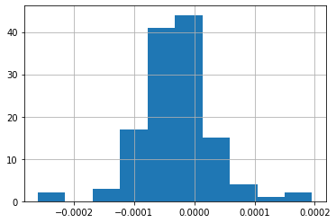

```python
delta['Percent diff'].hist()
```

```python
pls = delta.index[-1]
print('WORST PERLND SEGMENT IS', pls)
```

```
WORST PERLND SEGMENT IS 125
```

#### PERLND PWATER AGWLI

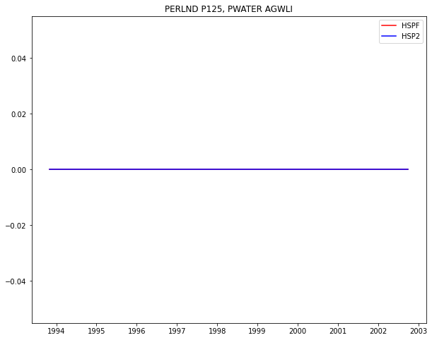

```python
plot('PERLND', pls, 'PWATER', 'AGWLI', 'sum')
```

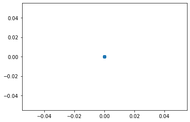

```python
scatter('PERLND', pls, 'PWATER', 'AGWLI', 'sum')
```

#### PERLND PWATER SURLI

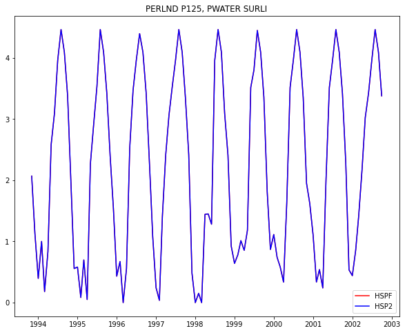

```python
plot('PERLND', pls, 'PWATER', 'SURLI', 'sum')
```

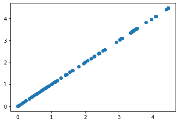

```python
scatter('PERLND', pls, 'PWATER', 'SURLI', 'sum')
```

#### PERLND PWATER AGWO

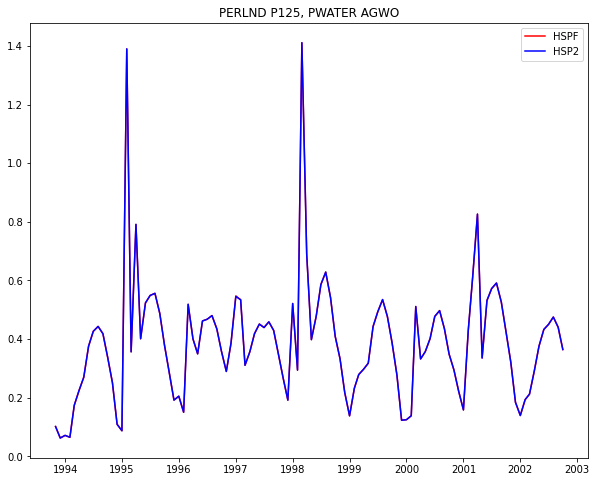

```python
plot('PERLND', pls, 'PWATER', 'AGWO', 'sum')
```

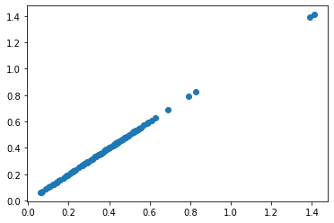

```python
scatter('PERLND', pls, 'PWATER', 'AGWO', 'sum')
```

#### PERLND PWATER BASET

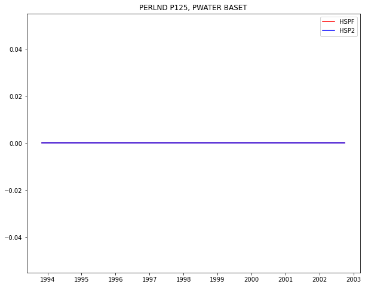

```python
plot('PERLND', pls, 'PWATER', 'BASET', 'sum')
```

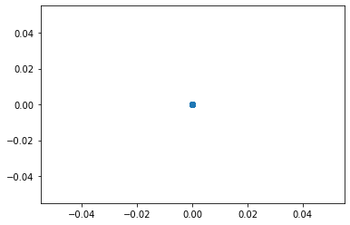

```python
scatter('PERLND', pls, 'PWATER', 'BASET', 'sum')
```

##### PERLND PWATER CEPE

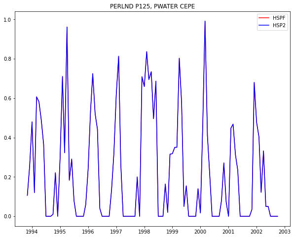

```python
plot('PERLND', pls, 'PWATER', 'CEPE', 'sum')
```

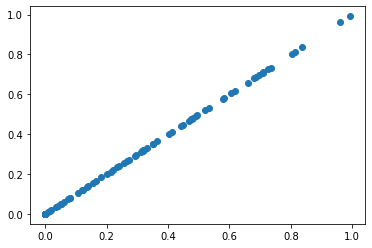

```python
scatter('PERLND', pls, 'PWATER', 'CEPE', 'sum')
```

#### PERLND PWATER IFWI

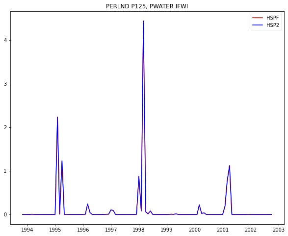

```python
plot('PERLND', pls, 'PWATER', 'IFWI', 'sum')
```

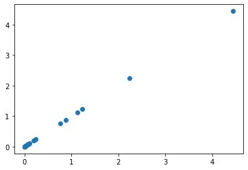

```python
scatter('PERLND', pls, 'PWATER', 'IFWI', 'sum')
```